# F1 Markdown Summary

Samuel Gurr

2023-01-14

- Last Updated: January, 2023

# Table of Contents

[output not shown]

# Multigenerational Bay Scallop OA Exposure

We successfully created the F1 bay scallop cohort in late July 2021. These bay scallops were raised to maturity and spawned in August 2022 to create the F2 generation (Figure 1). Here we present a brief update of the data we have collected over the past year and where we are in our overall experimental plans.

We have had many setbacks tin 2022 (Pseudomonas, pump failures, food issues, Vibrio), but after three spawnings, we were able to produce our F2 bay scallop generation. We collected a suite of physiology data during the F1 growout and Sam has made fantastic progress with library preparation for low coverage Whole Genome Sequencing and has sent his first test lane to be sequenced.

Live links to summaries of each life state / generation within the document:

### Big Picture Overview

- Figure 1: Experimental design.

**F1 Larval development**

**F1 Grow Out**

**F1 Physiology**

**F2 Larval development**

**F2 Grow Out**

**Chemistry**

## Big Picture Overview

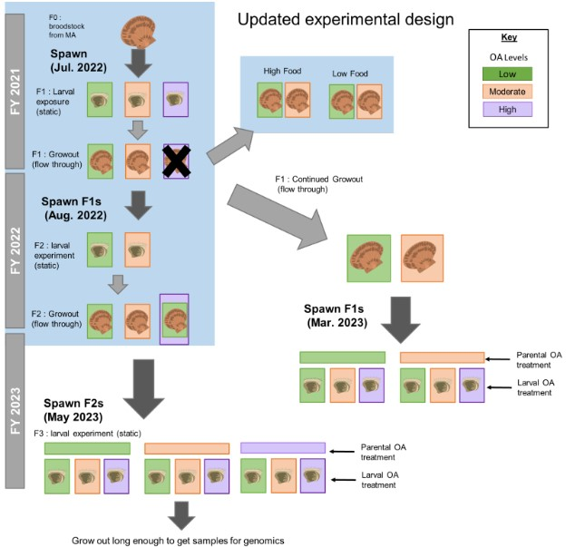

**Figure 1: Experimental design.** This figure has been adapted from our original proposal to reflect our current status and plans for FY23 and our final year of this project. Blue shading indicates stages that have been successfully completed and identifies where we are now in the three year plan. In the F2 growout, we used extra spat from the pH = 8 larval exposure to initiate a post settlement pH = 7 cohort. This is an alternative since we were not able to produce a pH=7 cohort that survived the larval exposure.

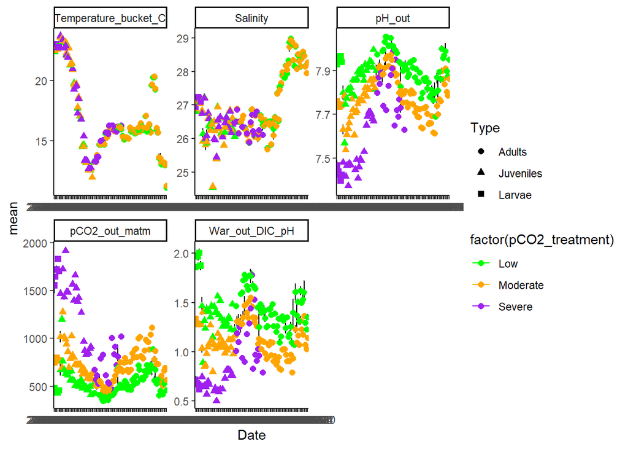

**Figure Figure 1 seawater chemistry.** Average pCO2, temperature, Salinity, and aragonite saturation state

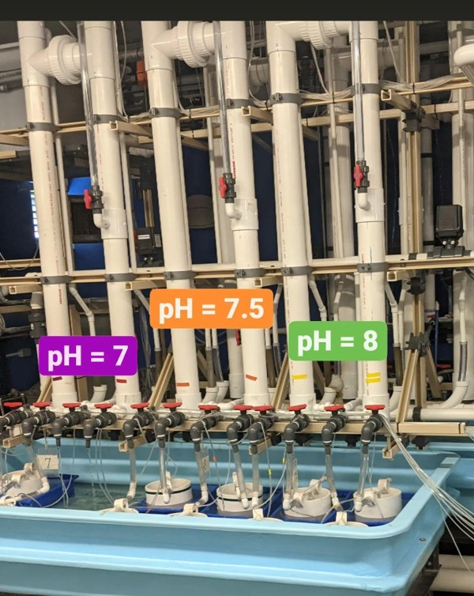

**Image 2: Experimental flow through set up** Experimental set up with downwellers and columns controlling pCO2 under flow through conditions. Although this does not directly represent the actual pH, we refer to the treatments as pH = 7, 7.5, and 8 for simplicity.

## F0 Broodstock and spawning

#### About Broodstock

In late July 2021 we spawned bay scallops produced from Massachusetts broodstock (F0). We had initially hoped for two populations, but the Connecticut population are now scarce and what few broodstock we did find, did not survive transport to the lab and the conditioning period.

#### Spawning and fertilization

Spawning was induced using thermal adjustments up to 25°C. When an individual was observed to be spawning, it was removed from the spawning table and placed in a 1-L beaker with filtered seawater at 25°C to continue releasing gametes. To avoid self fertilization, scallops were switched to new beakers frequently to isolate sperm and egg from each individual. When eggs were observed to be released, the animal was immediately switched to a new cup and eggs were caught on a 25µm sieve to remove any sperm that remained in the beaker. Prior to fertilization, sperm was rinsed through a 20µm sieve to remove any eggs that may have remained in the cup. Fertilizations were completed in batches to assure gametes were fertilized within approximately 1 hour of release and for each batch fertilization, each individual used contributed only sperm or only eggs to avoid self fertilization. Embryos were checked frequently to assure fertilization was occurring and gametes were not pooled until > 85% of the embryos showed clear cell division. Eggs were used from a total of 13 individuals and sperm from a total of 16 individuals, of these 6 individuals supplied both sperm and egg, but never to the same fertilization set.

## F1: First Generation

#### Exposure to treatments

After approximately 4 hours post fertilization, embryos from all batches were pooled and divided among 3 OA treatments (~400, 800, and 1600 µatm) with 5 replicates per treatment. Exposures were conducted in 10L filtered seawater at 27 psu and 23°C. Details of the chemistry for each OA treatment are detailed in Table 1.

| Treatment | pCO2 | pH | ΩAr |
| --- | --- | --- | --- |
| High OA | 1788 | 7.41 | 0.6 |
| Mid OA | 829 | 7.72 | 1.21 |
| Low OA | 474 | 7.93 | 1.85 |

### F1 Larval development

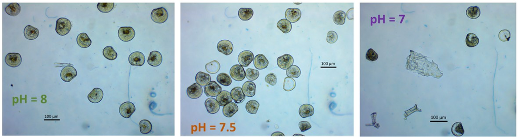

**Figure 2: Larval pictures at age 2 days.** Larval pictures at age 2 days post fertilization showing distinct differences in shell development to D stage.

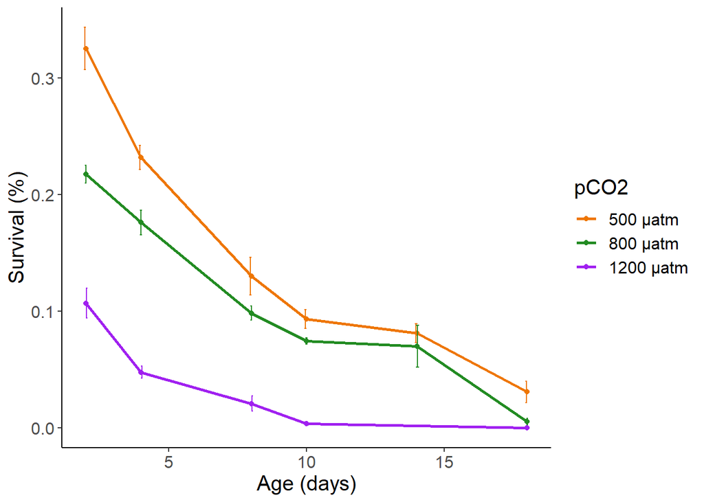

**Figure 2: F1 Larval Survival.** Survival over time. Error bars represent standard error. Settlement was evident by age 10 days, therefore survival counts are likely to be underestimations as a result of very sticky scallops making it difficult to suspend. (last updated 9/20/22)

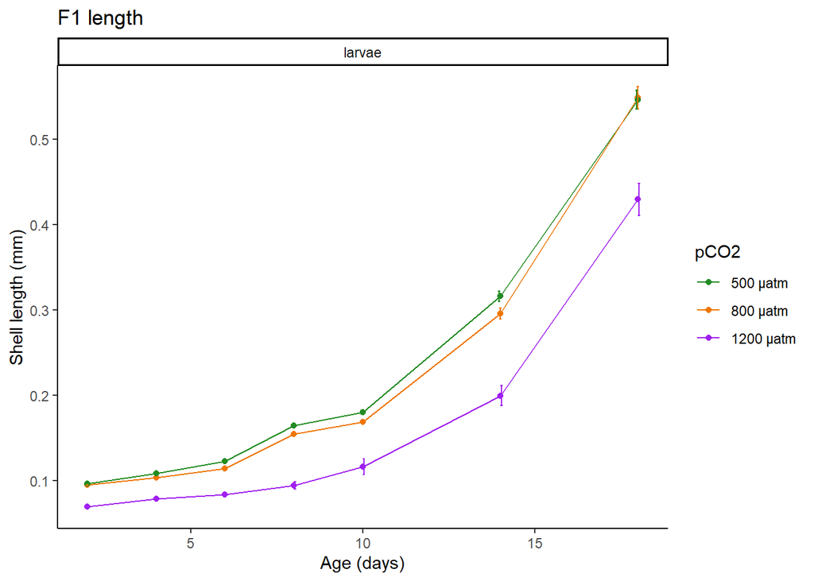

**Figure 3: F1 larval growth** Mean shell length overtime. Settlement was evident in the low and moderate OA treatments beginning at age 10 days.

## F1 Physiology

- Survival counts and shell length measurement were completed monthly and large batches of bay scallops were opportunistically frozen for dry weight measurements as cullings were required to prevent overcrowding.
- **Respiration Rate and Clearance Rate** were measured approximately monthly during the **early spat stages**.
- When the bay scallops were **large enough to move into the large respiration chambers** (out of the microrespiration system, 1.7mL), **Excretion Rates were also measured.**
- Once bay scallops were large enough **(> 20mm) the biodeposition method was used** to measure feeding metrics and clearance Rate.
- Physiological parameters were **not measured during the overwintering period** when metabolic activity is expected to be low, but resumed during the temperature ramp up in the late winter / early spring.

**Table 3 Log of physiology time points for F1 bay scallop grow out.** We are currently using length and weight data collected over the lifespan (September 2021-September 2022) to determine the best method for standardizing physiological rates to accomplish the most appropriate approach to metabolic scaling for our data. Once this is complete, we will include figures for these measurements that will be used to guide data collection during the F2 grow out.

[output not shown]

### Shell length

- length measured as the further points from the shell hinge
- data below only sown for the main tow treatments (low and Moderately elevated *p*CO2)

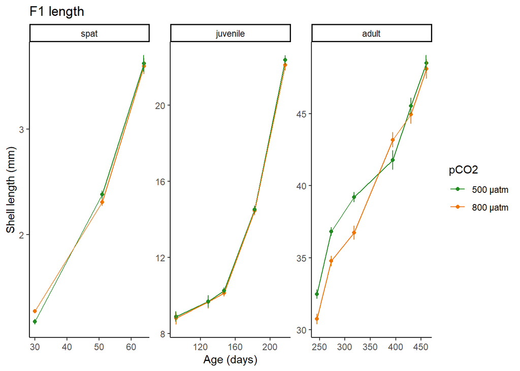

**Figure 8: F1 shell length spat - adult (high OA not included).** Mean +/- se for all data (note: not averaged by tank, but by treatment as whole). ‘Spat’ for all post-metamorphosis stage during initial move to downwellers and < 5mm shell length, ‘juvenile’ for all data >5 mm shell length and before ~8 months in age, ‘adult’ all time points thereafter.

### Respiration rates

#### **Respiration rates: Method**

**Respiration chamber volumes**

We use **two** instruments to measure oxygen conumption rates

1. **SDR Sensor plate**: a 24-well plate system for measuring oxygen consumption from embryo to spat stage - we have the plates to accomodate up to a well size of 1700ul and tethering up to three plates (72 total reads!). O2 is measured from detection of flourescent dyed-stickers adhered beneath each well. We measure as a static system in water-tight continaers submerged in a water bath - however there exists routes to agitate dishes while controlling temperature (i.e. shaker in an incubator for example)
2. **LoLigo 8-channel system**: when larvae/spat outgrow the SDR sensor dish, we move to a dipping probe system. Water is agitated with either magnetic stir bars (in small vessel system) or via an enclosed pump system (for large vessels). We have several sizes to accomodate species development spat - adult with unique vessel volumes listed below:

| Chamber_ID | Chamber_type | Chamber_volume | Instrument |
| --- | --- | --- | --- |
| 1 | x_small | 23.1 | loligo_8channel |
| 2 | x_small | 23.05 | loligo_8channel |
| 3 | x_small | 23.31 | loligo_8channel |
| 4 | x_small | 22.55 | loligo_8channel |
| 5 | x_small | 23.18 | loligo_8channel |
| 6 | x_small | 23.24 | loligo_8channel |
| 7 | x_small | 22.63 | loligo_8channel |
| 8 | x_small | 22.95 | loligo_8channel |
| — | — | — | — |
| 1 | small | 68.55 | loligo_8channel |
| 2 | small | 68.856 | loligo_8channel |
| 3 | small | 68.644 | loligo_8channel |
| 4 | small | 68.955 | loligo_8channel |
| 5 | small | 68.573 | loligo_8channel |
| 6 | small | 68.019 | loligo_8channel |
| 7 | small | 68.546 | loligo_8channel |
| 8 | small | 68.533 | loligo_8channel |
| — | — | — | — |
| 1 | medium | 196.6 | loligo_8channel |
| 2 | medium | 200.6 | loligo_8channel |
| 3 | medium | 201.4 | loligo_8channel |
| 4 | medium | 200 | loligo_8channel |
| 5 | medium | 199.2 | loligo_8channel |
| 6 | medium | 200.4 | loligo_8channel |
| 7 | medium | 201.3 | loligo_8channel |
| 8 | medium | 201.7 | loligo_8channel |
| — | — | — | — |
| 1 | large | 254.7 | loligo_8channel |
| 2 | large | 257.88 | loligo_8channel |
| 3 | large | 246.63 | loligo_8channel |
| 4 | large | 252.35 | loligo_8channel |
| 5 | large | 242.31 | loligo_8channel |
| 6 | large | 247.07 | loligo_8channel |
| 7 | large | 241.11 | loligo_8channel |
| 8 | large | 243.59 | loligo_8channel |

**Respiration: Biovolume calculated from shell length**

- verify linear relationship between measured biovolume and shell length^3
- obtain a ‘calculated’ vessel volume

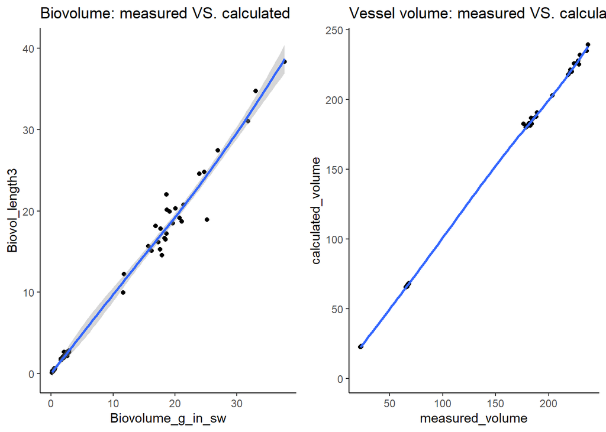

**Figure XX: biovolume calculated**. In cases when only shell lnegth was measured, it was required to calculate a biovolume representative of those individuals and correct for the volume of the chamber(s). The strong linear relationship supported using the calculated biovolume for all data for all time points estimated with the same standard

#### **Respiration: Raw(ish) rates**

- corrected for blank rates and the calculated vessel volume

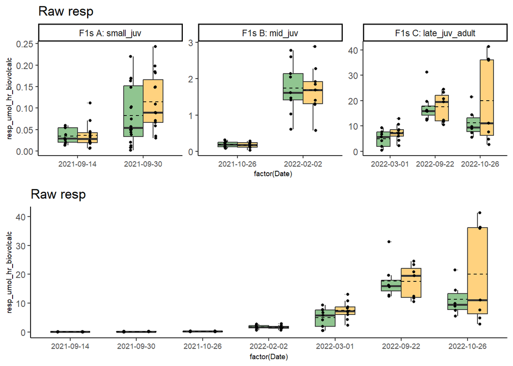

**Figure XX: F1 raw respiration data (umol O2 hr)**. Data is displayed parsed by developmental stages to facilitate viewing these data.

#### **Respiration: Metabolic scaling**

- determine the b factor the normalize all data.
- **NOTE**: since we have shell lengths for all individuals (as opposed to tissue dry weights) our team decided upon a b factor based on MO2 and shell length to normalize our data across all life stages
- b factor for all F1 data (based on shell length!) is **2.18**

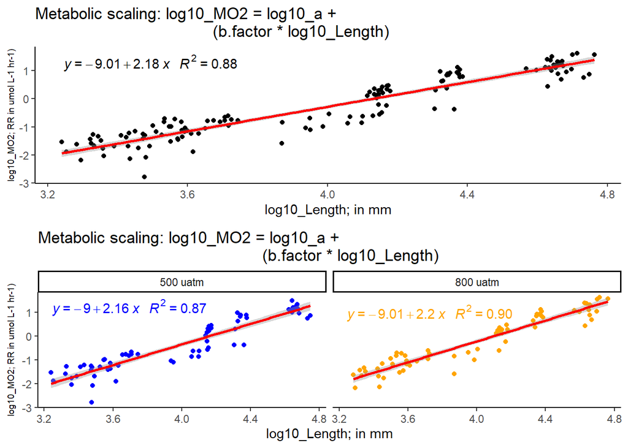

**Figure XX: F1 b factor plots** computed from the regression of log(shell length) and log(MO2).

#### **Respiration: Shell length normalized**

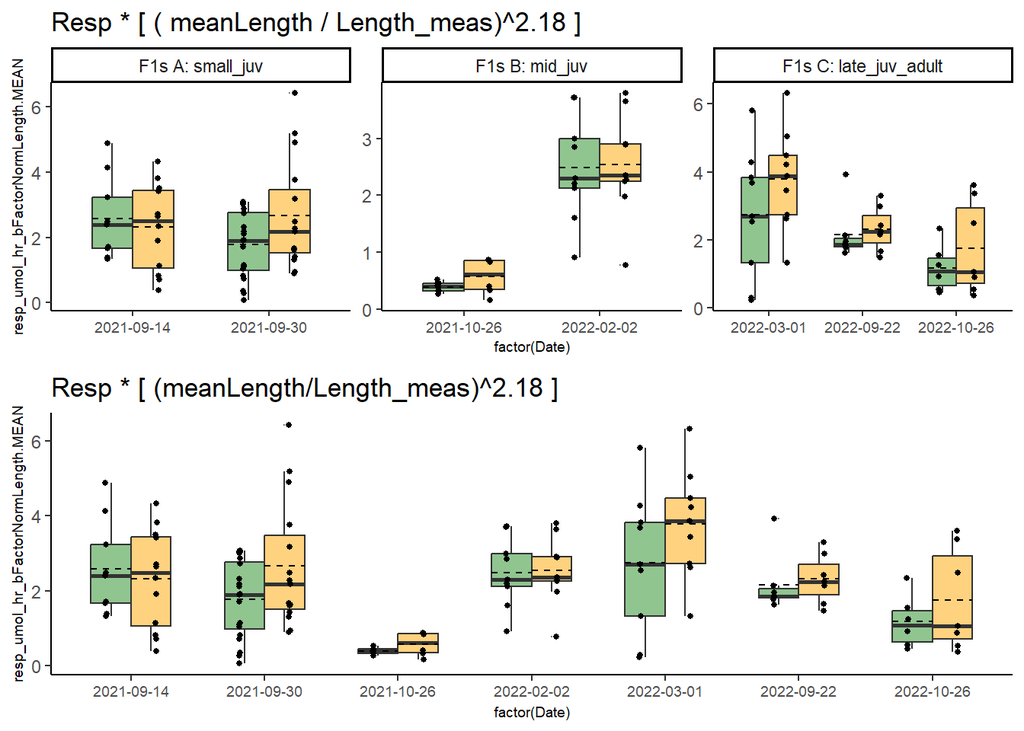

### Clearance rates

#### **Clearance rates: Shell length normalized**

- units as cells per mL per hour
- parsed by cell species and type as Chaetocerous, Tetraselmis (Ply), and seston
- length b factor normalized **2.18**

[figure not shown]

### Excretion rates

#### **Excretion rates: raw rates**

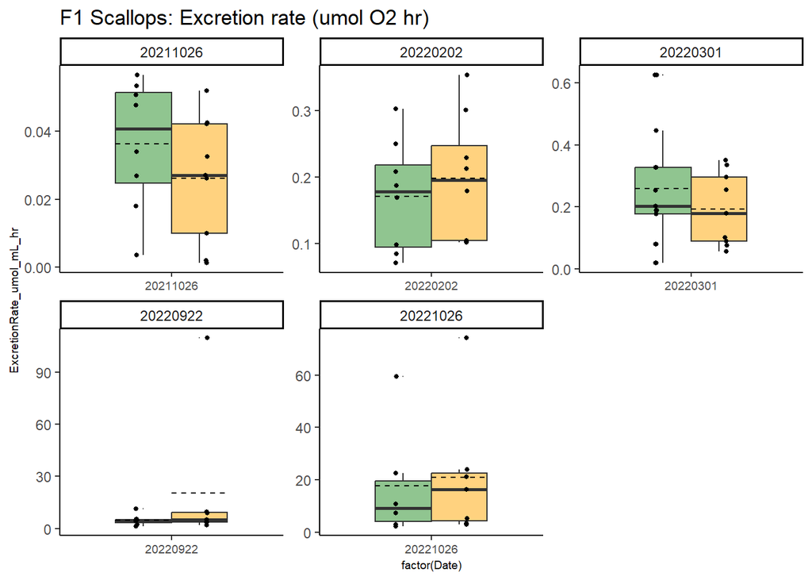

**Figure XX: F1 Excretion rates (umol O2 hr)**.

#### **Excretion rates: b factor**

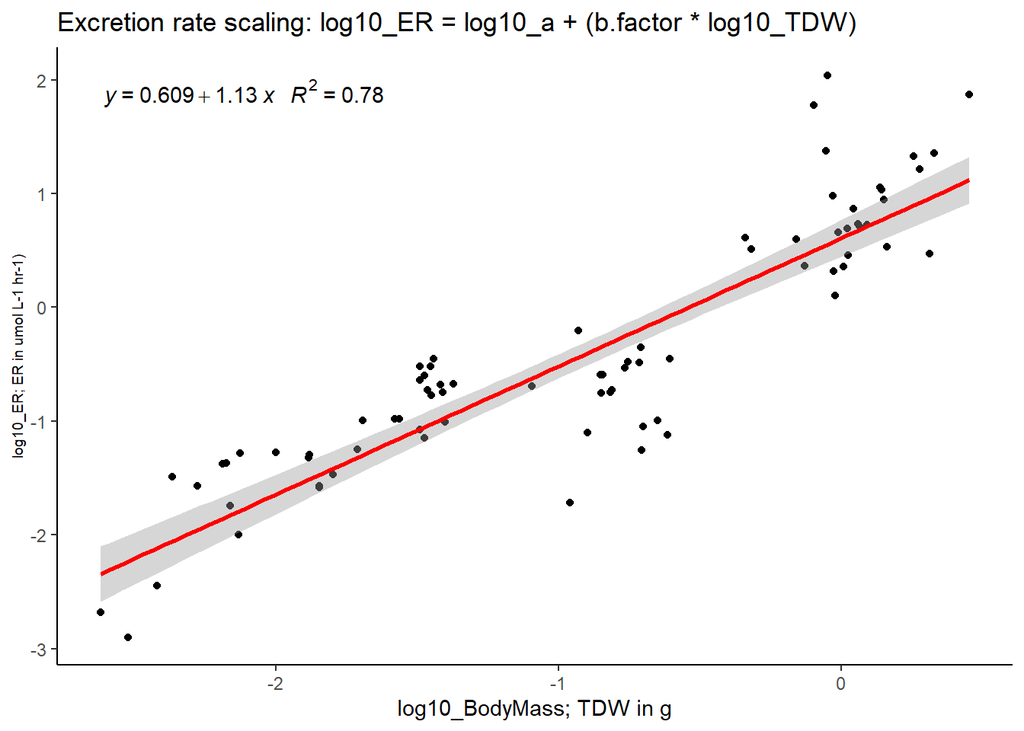

**Figure XX: F1 Excretion rates Tissue dry weight b factor plot**.

#### **Excretion rates: TDW normalized**

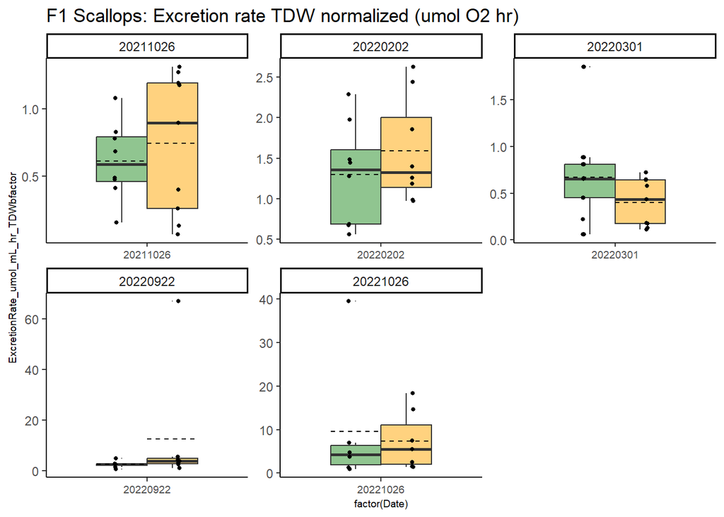

### O:N Ratio

#### **O:N Ratio: Method**

- Respiration rate (umol hr) as **start and end rate!**
  - Why compute this differently? since the ammonia excretoin value is represetnative of the entire incubation period, we want a O2 conumption value simple calculated as (start O2 - end O2 / time)
  - *Note* This is easier said than done, a large script of contingency statement was constructed for start.end RR due to (1) reoxygenation mid-trial for animals that reached 80% air saturation ealier than others (2) noise, air bubbles, etc.

#### **O:N Ratio: plotted**

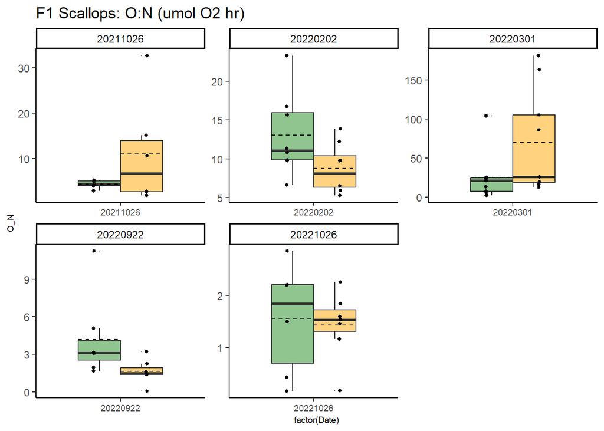

**Figure XX: F1 O:N ratio (umol O2 hr)**. Displayed are the Respiration data as startO2-endO2/time (umol O2 hr) and Excretion rates (umol O2 hr).

### Biodeposition

#### **Biodeposition: Method**

**Key for calculated metrics below:** * IER == Inorganic Egestion Rate: PIM of feces/feces collection time * OER == Organic Egestion Rate: POM of feces/feces collection time * IRR == Inorganic Rejection Rate: PIM of pseudofeces/pseudofeces collection time * ORR == Organic Rejection Rate: POM of pseudofeces/pseudofeces collection time * RR == Rejection Rate: ORR+IRR * p == Fraction of Organic Rejected: ORR/RR (organic fraction of the pseudofeces) * f == POM available: Average POM of the water * SE == Selection Efficiency: 1-(p/f) (organic content of pseudofeces/organic content of the water) * IFR == Inorganic Filtration Rate: IER + IRR (PIM feces + PIM pseudofeces; i.e. total inorganic matter filtered/collection time) * CR == Cleanrance Rate: IFR/PIM of the water * FR == Filtration Rate: CR * TPM of the water * %RR == RR/FR (amount rejected/total amount filtered) * TIR == Total Ingestion Rate: FR - RR * OFR == Organic FIltration Rate: CR * POM of the water * ORI == Organic INgestion Rate: OFR-ORR * i == Fraction of Organic Matter ingested: OIR/TIR (i.e. fraction of ingested material that was organic) * AR == Assimilation Rate: OIR-OER (rate of POM filtration - rate of POM rejection - rate of POM egestion) * AE == Assimilation Efficiency: AR/OIR

#### **Biodeposition: plotted**

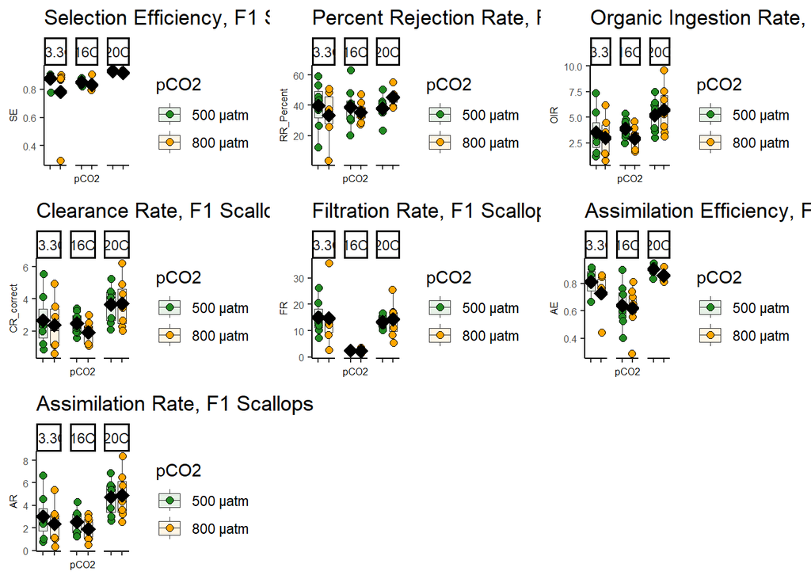

**Figure XX: F1 Biodeposition** shown below with assimilation efficiency (AE), assimilation rate (AR), organic ingestion rate (OIR), filtration rate (FR), rejection rate (RR)clearance rate (CR), selection (SE),

### Gene expression (F1s)

### SNPs & Genotype liklihoods (F1s)

**Table 2: Average Water Chemistry during the F2 grow out** (last updated 10/18/22). Using DIC and pH for the calculations.

Treatment pCO2 pH ΩAr High OA 1177 7.6 0.8 Mid OA 751 7.8 1.1 Low OA 543 7.9 1.4

### Larval development (F2s)

Several spawning attempts were made. Gonad development was evident in April and the first successful spawn was conducted. While spawning and fertilization was successful in April, after ~5 days of the full factorial experiment, it was evident that the larvae were crashing and after 10 days, 100% mortality was observed. Cause unknown. A second successful spawn was conducted in early July 2022, but at the water change and check at age 2 days old, heavy mortality was observed. After investigation, it was concluded that Vibrio was introduced through the food and the problem was fixed. A third and final spawn was conducted in late August 2022 with success (details below), but the egg output was low and we were unable to initiate the full factorial exposure and instead focused on just the creation of the F2 cohorts for each respective OA treatment (low and moderate - no high OA broodstock). Based on survival rates to date, we believe this was a wise decision. Fertilization rate was high (to first polar body), but progression to the multicellular stage after 4 hours was low (~20%). Food limitation (serious oyster population growing in the pipes from the harbor to the building) and several accidental spawnings due to pump failures while ripe scallops were being held could be part of the cause for a low output during this spawn.

### Spawning and fertilization

Spawning was induced using thermal adjustments up to 25°C. When an individual was observed to be spawning, it was removed from the spawning table and placed in a 1-L beaker with filtered seawater at 25°C to continue releasing gametes. To avoid self fertilization, scallops were switched to new beakers frequently to isolate sperm and egg from each individual. When eggs were observed to be released, the animal was immediately switched to a new cup and eggs were caught on a 25µm sieve to remove any sperm that remained in the beaker. Prior to fertilization, sperm was rinsed through a 20µm sieve to remove any eggs that may have remained in the cup. Fertilizations were completed in batches to assure gametes were fertilized within approximately 1 hour of release and for each batch fertilization, each individual used contributed only sperm or only eggs to avoid self fertilization. Embryos were checked frequently to assure fertilization was occurring and gametes were not pooled until > 85% of the embryos showed clear cell division. Spawnings for the two cohorts (low and moderate OA) were conducted simultaneously and the number of males and females contributing to each cohort were kept constant. Eggs were used from a total of 11 individuals and sperm from a total of 11 individuals, of these 4 individuals supplied both sperm and egg, but never to the same fertilization set.

Exposure to treatments After approximately 4 hours post fertilization, embryos from all batches were pooled and divided among 2 OA treatments (~400 and 800 µatm) with 3 replicates per treatment. Exposures were conducted in 10L filtered seawater at 27 psu and 23°C. Eggs were overstocked because of observations of stunted fertilization, so an initial embryo density was not accurately determined. Day 2 stocking density was 5-6 larvae / mL. Details of the chemistry for each OA treatment are detailed in Table 4.

**Table 4: Average Water Chemistry during the F2 larval experiment** using DIC and pH for the calculations.

Treatment pCO2 pH ΩAr Mid OA 787 7.8 1.5 Low OA 386 8.0 2.6

Low OA Moderate OA Mean Shell Length (µm) 350.6 µm 320.6 µm Mean Survival (%) 2.70% 0.90% Mean Successful Metamorphosis (%) 59.4% 8.8%

### Grow Out (F2s)

F2 bay scallops were moved to the basement flow through system at age 23 days post fertilization and reared in downwelllers on 200µm mesh on drumfiltered seawater (30µm) at a temperature of ~22°C and salinity of 27-29. Spat were evenly distributed across 12 downwellers (n=4 for pH = 7.5 and n = 8 for pH =8). The first real counts were conducted 2 weeks after moving to the basement (9/21/22; age 36 dpf) and all downwellers were standardized to ~100 individuals per downweller. In addition to food coming in with the seawater from the harbor, diet was also supplemented with cultured phytoplankton (Chaet, T. iso, and PLY).

The rationale for this is to obtain some physiological data under more extreme OA conditions. Because we were not able to produce larvae that could survive the extreme condition, exposure beginning as spat will help us to understand if other life stages are resilient to OA. Due to low survival in the pH = 7.5 during the static larval exposure, we did not have the numbers needed to also expose pH=7.5 spat to a pH=7 without risk of losing numbers and broodstock for a spawn to create the F3 generation, which is the primary goal of this project.

Growth and survival will be monitored approximately monthly and physiology will be measured opportunistically when destructive sampling is feasible (ie. the main focus is rearing enough to have good broodstock numbers, so destructive sampling will only occur when a culling is required to reduce densities).

Destructive sampling for genomics will be conducted during the first large culling requirement (November 17-18, 2022) and only the minimum number required will be sampled.

Table X: Log of physiology time points for F2 bay scallop growout.

| Date | Age(dpf) | Temp | Platform for Respiration | Excretion | Feeding |
| --- | --- | --- | --- | --- | --- |
| Aug 30, 2022 | 14 | 23°C | Microrespiration (80uL chambers) | no | no |
| Sept. 21, 2022 | 36 | 20°C | Microrespiration (80uL chambers) | no | no |
| Nov. 16, 2022 | 92 |  |  |  |  |

### Physiology (F2s)

### Gene expression (F1s)

### SNPs & Genotype liklihoods (F1s)

Food CHGRA - Chaetoceros muelleri Chaet B - Chaetoceros neogracile Ply429 - Tetraselmis chui Mono - Diacronema lutheri (previously Pavlova lutheri)